# Examining Class Types:Impact on Average Math Scores

Hee Won Ahn

2024-03-18

# 1. Abstract

The purpose of this report is to investigate the impact of class size on first-grade student’s mean math scores using the Tennessee Student/Teacher Achievement Ratio (STAR) dataset. We aim to explore the purpose and motivation of our analysis in the introduction while examining the overall short summary (source, target, sampling method) of dataset in the background. We will conduct descriptive analysis to visually explore variables relevant to our primary question with plots and tables. Furthermore, we will apply our statistical model (Two-Way Anova Model) in inferential analysis to address our primary question. Lastly, we will execute a sensitivity analysis to evaluate the robustness of our model.

Improvements compared to initial report are:

We conduct extended analysis to answer our third question of interest. we seek to identify and understand the variables that contribute to variations in academic performance within school level factors by focusing on mean math scores per school. We also omitted unnecessary plots and tables from the initial report and included explanations for our findings (Tukey’s range test) for better interpretation.

# 2. Introduction

The primary focus of this analysis is to delve into the impact of class size on student performance, leveraging insights from study Tennessee Student Teacher Achievement Ratio (STAR) randomized experiment by the Tennessee General Assembly and conducted by the State Department of Education.

We aim to answer two key questions of interest:

1. Are there discernible differences in math-scaled scores among 1st grade students across different class sizes?
2. Which class size is most strongly associated with higher math-scaled scores in 1st grade?

By answering these questions, this analysis aims to provide valuable insights into the relationship between class size and academic performance in mathematics education during the early year of schooling (1st grade).

Results and findings of our analysis may be used by policy makers to optimize class size to enhance overall students learning and we may contribute to society by suggesting effective educational strategies and system.

We also aim to answer one more question of interest in extended analysis:

3. what factors influence the average math scores across different schools?

This additional research question enhances the depth of our analysis and provides valuable insights into the broader context of educational outcomes. Also, this question may answer why school ID indicator should be included in our two-way ANOVA model in inferential analysis.

# 3. Background

During the experiment, students from kindergarten through third grade (K-3) were randomly assigned to three different class sizes:

1. Small (15-17 students)
2. Regular with Aide (22-25 students)
3. Regular (22-25 students)

The academic performance of students (math, reading, listening, etc) was evaluated by using the Stanford Achievement Tests (SATs) made by the Psychological Corporation in 1983.

A collective of 79 schools engaged in this experiment, surpassing more than 7,000 students annually. Each school involved in the STAR project was equipped with at least one of all three class types, and students were assigned to different class types through random allocation.

The STAR dataset contains information on 11,601 students who participated in the experiment with significant proportion of missing values. It includes a variety of data which contains demographic variables, school and class identifiers, details about schools and teachers, experimental conditions (class types) and scores from achievement tests (SAT).

Given our goal of examining the impact of class size on first-grade math scores, relevant variables in the dataset include:

- information of students (gender, race, date of birth, presence of free lunch, attendance)
- Class type variables (small, regular, regular with aide)
- School details (urbanicity, school ID)
- Teacher information (teacher ID, years of teaching experience, teaching career, demographic details)
- First-grade math scores of students.

In our analysis, since our primary goal aligns with the relationship between class size and grade 1 math score, we only focus on variables related to 1st grade students, school, and teachers.

# 4. Descriptive analysis

At first, we obtain the variables from `STAR` data set that is only related to answer two primary questions, whether there are any differences in `math scaled scores` in 1st grade across `class types`, and if so, which `class type` is associated with the highest `math scaled scores` in 1st grade.

we will explore the data sets and find summary statistics to examine the structure and characteristics of the data. Since we only examined the math scores in 1st grade in this project, we deleted columns unrelated to 1st-grade math scores such as reading scores.

- `math1`: total math scaled score in 1st grade
- `teacher_experience`: years of teacher’s total teaching experience in 1st grade
- `school_id`:factor indicating school ID in 1st grade
- `class_type`:factor indicating the STAR class type in 1st grade: regular, small, or regular-with-aide
- `teacher_id`: factor indicating teacher ID **the basic unit of our analysis**
- `school_urban`: School urbanicity of school (suburban, rural, urban, inner city)
- `teacher_career` :Teacher career ladder level grade 1
- `teacher_degree` : Teacher highest degree grade 1

**Missing Values**

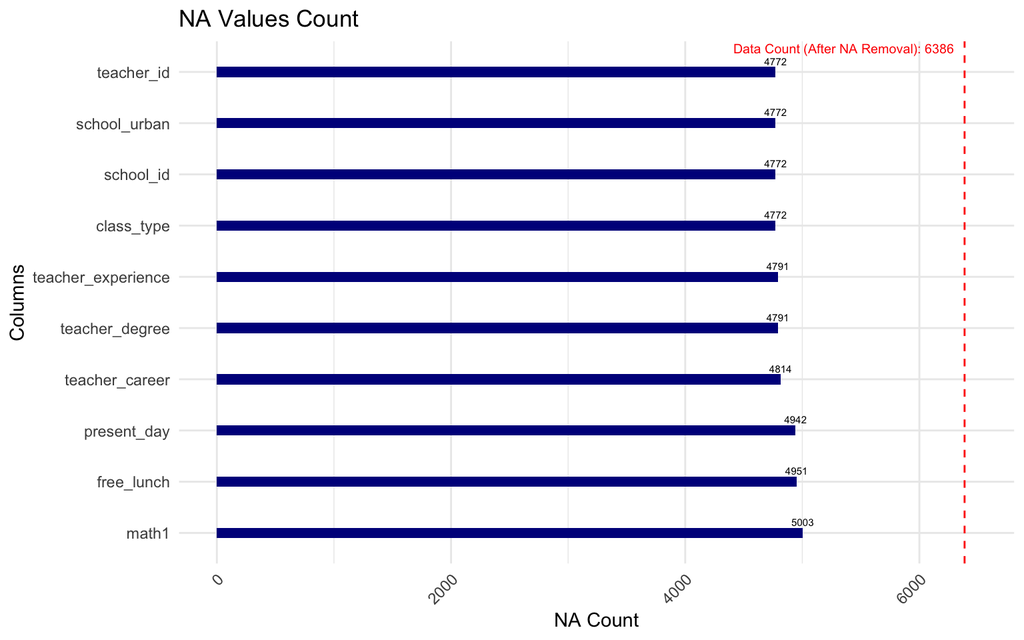

We decide to remove NA values for following reasons:

1. Data Integrity: Removing NA values helps maintain the integrity of the dataset since data set contains complete and accurate information.
2. Sample Size Consideration: Dataset still contains over 6000 Dataset which is large sample size that may provide sufficient statistical power for meaningful analysis and robust conclusions.
3. Even distribution of class sizes: Distribution of class sizes across school IDs are still even after removing NA values which aligns well with our goal of this analysis

##### Two variables representing ID’s

| ID | teacher_id | school_id |
| --- | --- | --- |
| Number of levels | 335 | 76 |

##### Frequency table of four qualitative variables

###### class_type

| Class.Type | Count |
| --- | --- |
| small | 1821 |
| regular | 2433 |
| regular+aide | 2132 |

###### school_urban

| School.Urban | Count |
| --- | --- |
| Inner city | 1291 |
| Suburban | 1524 |
| Rural | 2983 |
| Urban | 588 |

###### teacher_degree

| Teacher.Degree | Count |
| --- | --- |
| Bachelors | 4144 |
| Masters | 2184 |
| Specialist | 37 |
| Doctoral | 21 |

###### teacher_career

| Teacher.Career | Count |
| --- | --- |
| chose not to be on career ladder | 482 |
| Apprentice | 689 |
| Probation | 619 |
| Ladder level 1 | 4224 |
| Ladder level 2 | 104 |
| Ladder level 3 | 268 |

##### Summary statistics of two quantitative variables

###### math score

| value | math1 |
| --- | --- |
| minimum | 404.00 |
| 1st quantile | 500.00 |
| Median | 529.00 |
| Mean | 530.80 |
| 3rd quantile | 557.00 |
| maximum | 676.00 |
| standard deviation | 43.12 |

###### teacher_experience

| value | experience |
| --- | --- |
| minimum | 0.00 |
| 1st quantile | 4.00 |
| Median | 10.00 |
| Mean | 11.58 |
| 3rd quantile | 17.00 |
| maximum | 42.00 |
| standard deviation | 8.93 |

Based on the observed histogram of total math scaled scores in the 1st grade, which appears to approximate a normal distribution form histogram and qqplot, we have selected the **mean** as an appropriate summary statistic, we have added a variable accordingly.

- `mean_math_score` : the average math score per teacher (each class uniquely identified by its assigned teacher)

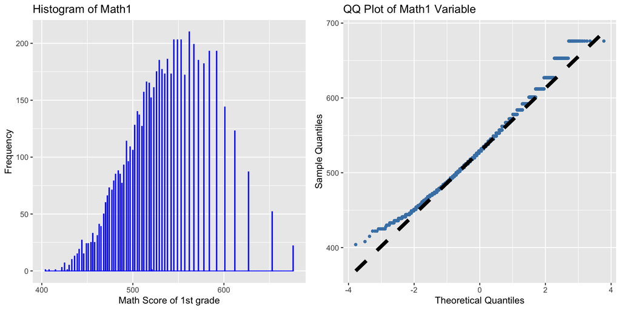

**Mean math score for each teacher**

| value | mean_math_score |
| --- | --- |
| minimum | 468.3 |
| 1st quantile | 514.2 |
| Median | 531.0 |
| Mean | 530.8 |
| 3rd quantile | 547.4 |
| maximum | 609.7 |
| standard deviation | 25.02. |

The mean and median are close, suggesting that the data roughly follows a normal distribution. This indicates a relatively even distribution of mean scores per teacher. The minimum value is 468.3 and the maximum value is 609.7, indicating a range of approximately 141.4. This suggests that the spread of data is large.

**Multivariate descriptive of mean math score per teacher**

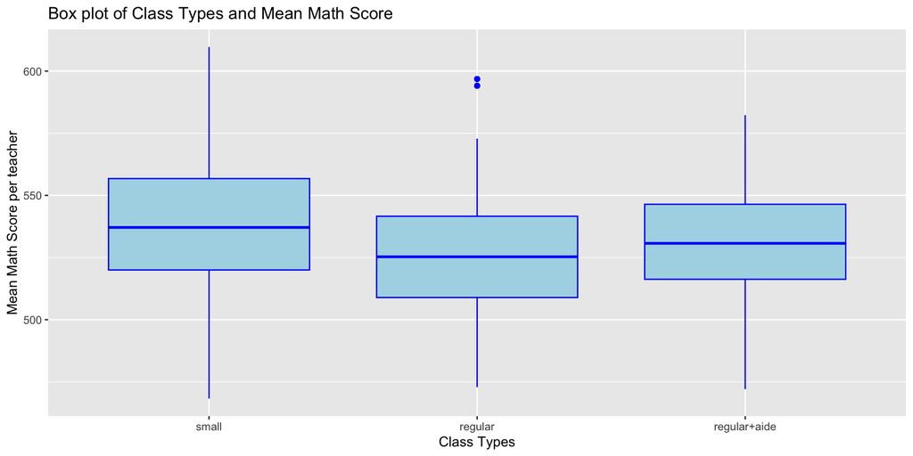

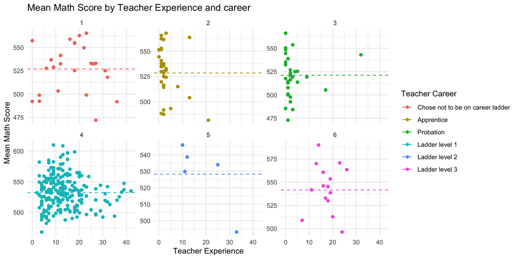

In practice, we might assume a positive linear relationship between a teacher’s experience and students’ mean math score. However, the scatter plot suggests that there is no significant linear relationship between teaching experience and mean math score for each teacher.

Therefore, analysis regarding teacher experience and career are unnecessary for further investigation.

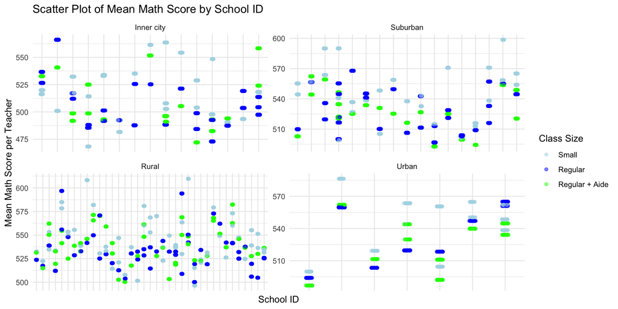

For urbanicity, when school ID is classified as “inner city” math scores tend to be lower compared to other area. Further analysis is needed for this variable. Additionally, most schools are situated in rural areas. Class sizes are uniformly distributed across each school, suggesting that each school has a consistent range of class sizes. Therefore, including school ID as a variable and examining the effect of class size when it is fixed may provide insights into the impact of class size on academic performance.

**Given the potential difference in mean math scores across different schools above, it would be insightful to explore visualizations depicting the distribution of mean math scores per school**

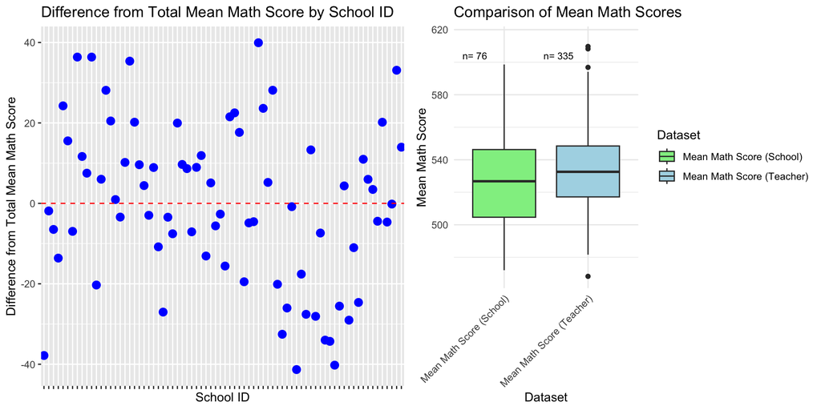

- `mean_math_score_school` : the average math score per school

Despite our small sample size is not enough to fully investigate larger variability in mean scores per school, further analysis will be helpful to understand which underlying factors contribute to these significant variations.

while `class types` appear to be an important measure in project `STAR`, the significant variation observed among schools suggests that `school-level factors` may also play a crucial role.

We will conduct further analysis on factor related to School ID on extended analysis.

# 5. Inferential analysis

### 5.1 Model selection

We use an **imbalanced two-way ANOVA model without interaction** in this data for the following reasons.

1. Two explanatory variables are affecting the response variable.
2. The number of observations varies across cells.
3. Our main goal is to examine the class size’s main effect, so we’ll exclude the interaction term to focus solely on evaluating each variable’s individual effects.

We choose to include the `class type` factor and `school ID` for each corresponding reasons:

1. Our primary interest lies in assessing the main effect of class size.
2. Changes in mean math scores may be influenced by factors related to the school, such as school quality or location. Therefore, it’s essential to consider the potential influence of the school to focus solely on class size effect.

The model we use is as follows:

$$Y_{ijk} = \mu_{\cdot\cdot} + \alpha_i+\beta_j +\epsilon_{ijk}, \
k=1,\ldots, 335 \ \ i=1,\ldots, 3 \ \ j=1, \ldots, 76$$

- $Y_{ijk}$ = expected mean math score of the $i$th class type, $j$th school, and $k$th teacher.
- $\mu_{\cdot\cdot} = \sum_{i=1}^a\sum_{j=1}^ b\mu_{ij}/(ab)$: population mean of scaled math score within each cell determined by class type and school indicator.
- $\alpha_i=\mu_{i\cdot} - \mu_{\cdot \cdot}$: main effect of the ith class type.
- $\beta_j=\mu_{\cdot j}-\mu_{\cdot\cdot}$: main effect of the jth school.
- $\epsilon_{ijk}$: random error in the $i$th class type, $j$th school, and $k$th teacher.
- $\mu_{i\cdot} = \sum_{j=1}^b \mu_{ij} /b$
- $\mu_{\cdot j}=\sum_{i=1}^a \mu_{ij}/a.$
- $\sum_{i=1}^a\alpha_i=0 ,\ \sum_{j=1}^b\beta_j=0$
- $i$: represents the class types: 1 for “small”, 2 for “regular”, and 3 for “regular with aide”.
- $j$: index of the school indicator. We have total 76 schools.
- $k$: index of teachers in the $i$th class type and $j$th school. We have total 335 teachers.

Assumptions on parameters are as follows:

- $\{\epsilon_{ijk}\}$ are i.i.d. $N(0,\sigma^2)$ where $\sigma$ is a constant
- The observations are independent of each other.
- The effects of the class type and school indicator on the response variable are additive where no interaction between these factors exists.

We choose **Type II** two-way ANOVA model because of the following reasons:

- The sums of squares in Type I ANOVA differ based on variable order.
- Type II ANOVA enables the calculation of variance explained by each variable independently, focusing solely on their unique contributions, aligning with our specific goal.
- In the absence of an interaction term, Type II is the preferred choice.

**Fitted results**

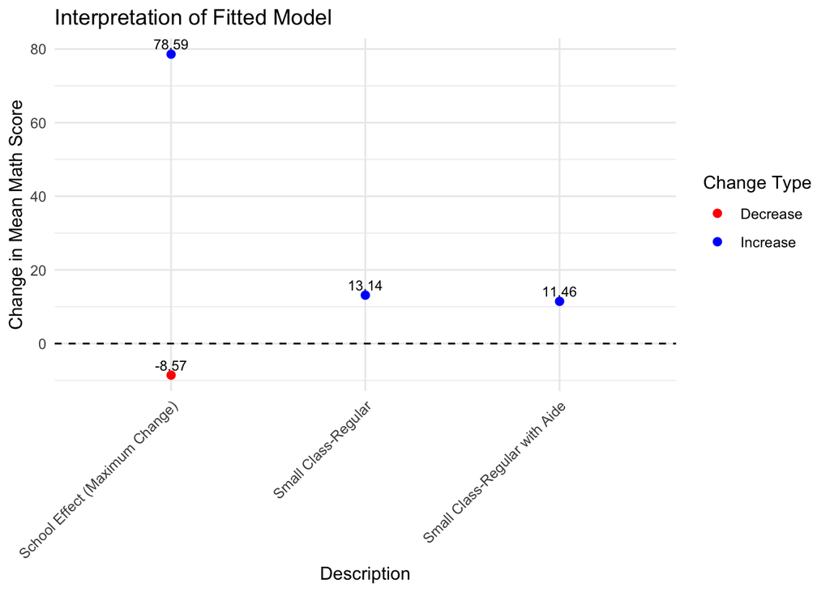

From the fitted model we may interpret our result by:

- When the school ID is fixed, the mean math score is expected to increase by 13.14 when the class size is small compared to when it’s regular.
- Similarly, when the school ID is fixed, the mean math score is expected to increase by 11.46 when the class size is small compared to when it’s regular with aide.
- When class size is held constant, the expected increase in the mean of math scores is up to a maximum of 78.59, while the expected decrease is up to a maximum of 8.57. This suggests that the school to which students are assigned also plays a significant role in estimating the mean math score.

### 5.2 Hypothesis testing

**ANOVA Table**

| source | sum of square | degree of freedom | F values | p-value |  |
| --- | --- | --- | --- | --- | --- |
| class_type | 11675 | 2 | 20.70 | 4.631e-09 |  |
| school_ID | 133936 | 75 | 6.33 | <2.2e-16 |  |
| residuals | 72486 | 257 |  |  |  |

we conducted an F-test for the `main effects of class types` to answer our first primary question of interest: whether there are any differences in math scaled scores in 1st grade across class types.

Since our ANOVA model is type II, We define the sum of squares as

- Main effect due to Factor A: ${\rm SSE}_{B}-{\rm SSE}_{A,B}$
- Main effect due to Factor B :${\rm SSE}_{A}-{\rm SSE}_{A,B}$

Given null hypothesis for testing the main effects of class type is

$H_0: α_1=α_2=α_3$

where each $α_i$ represents the average of the mean test scores within each class type.

The alternative hypothesis is

$H_1$: not all $α_i’s$ are equal

Our $F^*$ is $\frac{MSTR_(classtype)}{MSE_(residuals)}=20.70$

From the ANOVA Table, it is observed that the p-value is less than 0.05. Consequently, we may reject the null hypothesis and conclude that there is a main effect of the class types at a given significance level of 0.05.

**Tukey’s range test**

We conducted Tukey’s method provides insights into the confidence intervals for differences in means across all pairs of class types to answer our second primary question of interest: which class type is associated with the highest math scaled scores in 1st grade

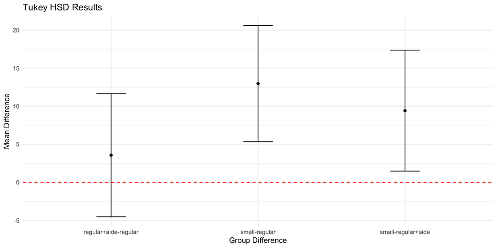

By comparing regular classes with regular classes having an aide on the tukey’s test, we find that the 95% confidence interval contains zero. This suggests that there is no significant difference between these factors at the significance level 0.05.

However, by examining the confidence intervals for the other two comparisons (small with regular, small with regular+aide), we observe that they do not contain zero. This leads us to conclude that there exist significant differences between small class types and others at the significance level 0.05.

This test indicates that small class size is associated with the highest mean math scores in 1st grade.

Result of our analysis can be interpreted by:

Smaller class sizes may benefit students by promoting individualized attention, reducing distractions, and increasing student participation, which may lead to higher academic performance of math score students.

# 6. Sensitivity analysis

### 6.1 Model Diagnostics

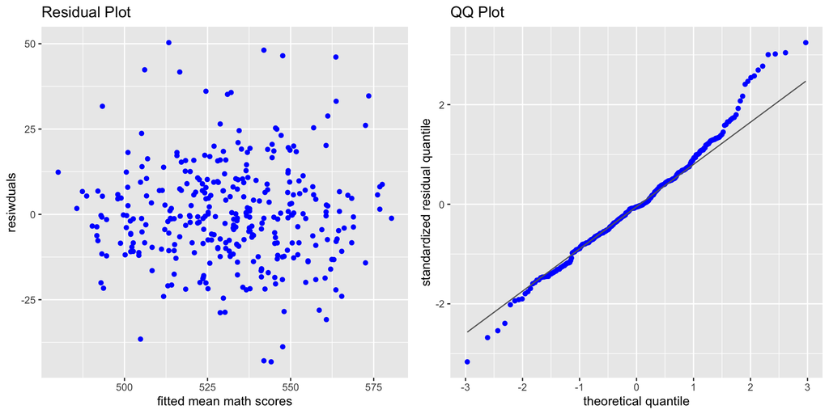

- **Equal Variance Assumption**: According to the Residual Plot, It is hard to detect any patterns but there are residuals that are on the extreme side, so we conducted `Leven's test` to check equal variance. Test output implies that the p-value is 0.09, we cannot reject the null hypothesis and indicates that we may conclude that variance among groups is the same at a significance level of 0.05.
- **Normality Assumption**: According to the QQ plot, we can detect heavy tails on both ends, therefore normality assumption may be violated. We take `The Shapiro-Wilk test` for deeper analysis. Since the P-value of the test is less than 0.05, we may reject the null hypothesis and conclude that the data does not follow normal distribution. To solve the non-normality issue, we conducted a `box-cox` transformation of the response variable as a remedy. However, the transformed response variable still rejects the null hypothesis at the 0.05 significance level. we decided not to apply Boxcox transformation for our model.
- **Independence Assumption**: According to the `Durbin-Watson test`, the Test output implies that the P-value is 0.42, we cannot reject the Null hypothesis and may conclude that errors are independent of each other. The result of this test is crucial because one of the fundamental assumptions of of our model is that the residuals are independent of each other.

### 6.2 Median as a summary measure

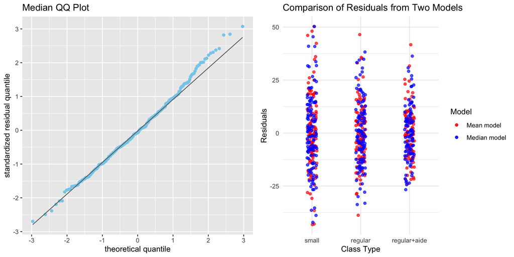

**Table Comparing mean absolute value of residual of two models**

| Class size | Mean as a summary measure | Median as a summary measure |
| --- | --- | --- |
| Small | 12.43 | 13.89 |
| Regular | 10.97 | 12.04 |
| Regular + Aide | 9.57 | 10.26 |

After exploring the possibility of using the median as an alternative summary measure for remedy of non-normality issue,we found that the p-value of the `Shapiro-Wilk test` and the QQ plot above indicate the normality of standardized residual. However, the P-value of `Levene's test` using the median is less than 0.05, indicating that when applying the median instead of the mean, violates the assumption of equal variance. Additionally, When comparing the mean of the absolute values of residuals across groups by plot and table above, we can confirm that the violation of equal variance is larger when the median is applied as a summary measure.

We have decided to keep **mean** as our summary measure for our analysis even though the median does not violate the normality assumption because our primary goal is to compare representative values across different class sizes and the unequal equal variance assumption could significantly impact the precision of the estimated effects which does not align with our goal.

# 7. Discussion

We used the STAR data to answer two main questions: Are there differences in math-scaled scores among 1st-grade students across different class sizes? If so, which class size is most strongly associated with higher math-scaled scores in 1st grade?

The inferential analysis revealed that there exist differences, with the smallest class size being most strongly associated with higher math-scaled scores in grade 1. When compared to regular classes and regular classes with an aide, small class sizes are expected to result in an increase of 13.14 and 11.46 points in mean math scores respectively.

From the result of the analysis, potential reasons for higher mean math scores in smaller class sizes may be due to individualized attention, reduced distractions, tailored instruction, and increased student participation.

Based on the given results, some suggestions are:

1. Considering the positive relationship observed between smaller class sizes and higher math scores, school administrators may consider policies to reduce class sizes. Since our research indicates a positive association between smaller class sizes and academic performance, reducing class sizes could potentially enhance the academic outcomes of students.
2. Additional research could be conducted based on these research findings. For instance, investigating whether the relationship between smaller class sizes and math scores persists in different grades or subjects could be explored. Such research could provide further insights and have a greater impact on educational policies and practice.

The strength of the STAR experiment exists in its randomized assignment of students to different class size conditions (small, regular, and regular with a teacher aide), thorough monitoring by graduate students, large sample size exceeding 10,000 students, and longitudinal follow-up over four years from kindergarten to third grade. These aspects ensure the integrity of the experimental design, minimize biases and provide valuable insights into the impact of class size on academic performance.

In the extended analysis, it became evident that additional support related to education for low-income students should be made. Direct policies targeting students’ academic needs could be beneficial. Moreover, having more school-related data would be advantageous. The current dataset does not provide sufficient variables for analyzing school-level average scores effectively.

# 8. Extended Analysis

We have examined how the type of class may impact the mean math score. Furthermore, We want to explor other factors that could potentially influence students academic performance.

During the descriptive analysis above at 4, We observed significant differences in average scores across different **school IDs**. This made me to think about the underlying reasons for such variations.

We hypothesize three factors: differences in parental `income levels` among schools, `variations in school locations`, and potentially diverse average `attendance rates` among school.

We may speculate that these three differences might ultimately influence the students math scores.

At first, we will explore relationship between three factors below and School ID and if association is found, we will find out how these factors can influence math school of first grade students,

- `mean_math_score_school` : the average math score per school
- `mean_attendance`: mean school attendance rate per school
- `school_urban`: geographical location of the school
- `free_lunch_ratio`: mean ratio of students with Free Lunch per school, factor that may represent parental income level. (students not receiving free lunch are presumed to come from higher-income families)

**All variables in the analysis are grouped by `school_ID`**

### 8.1 Exploratory Data Analysis for extended analysis

##### Summary Statistics of three quantitative variables for extended anaylsis

###### mean_math_score_school

[output not shown]

###### mean_attendance

| Summary | value |
| --- | --- |
| minimum | 137.5 |
| 1st quantile | 145.4 |
| Median | 148.0 |
| Mean | 150.5 |
| 3rd quantile | 152.3 |
| maximum | 173.7 |
| standard deviation | 8.6 |

###### Free_lunch_ratio

| Summary | value |
| --- | --- |
| minimum | 0.03 |
| 1st quantile | 0.32 |
| Median | 0.43 |
| Mean | 0.51 |
| 3rd quantile | 0.70 |
| maximum | 1.00 |
| standard deviation | 0.27 |

##### Frquency table of school_urban for extended anaylsis

###### School_Urban

| Class.Type | Count |
| --- | --- |
| Inner city | 15 |
| Suburban | 17 |
| Rural | 37 |
| Urban | 7 |

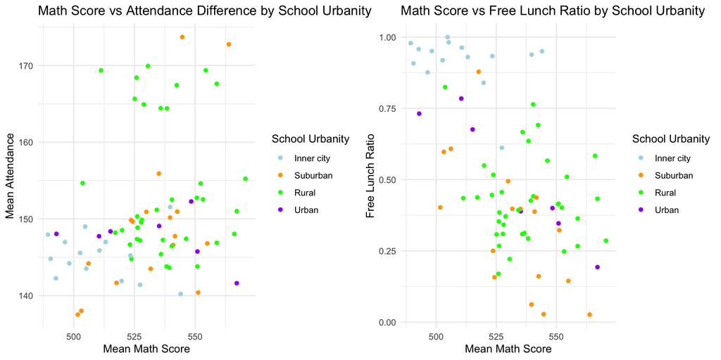

When examining the two figures above, it appears that there is no clear linearity between attendance and average math scores. Additionally, there seems to be a linear decrease in math scores as the number of students receiving free lunch increases. Furthermore, schools located in inner city areas generally have lower math scores, and a higher ratio of students receiving free lunch. This suggests that students from lower-income families tend to reside in inner city areas.

### 8.2 Regression Analysis for extended analysis

When considering urbanicity, a linear relationship between mean math scores appears evident in the case of Inner city. However, since Inner city areas exhibit high levels of free lunch, as seen in the figure above, analyzing based solely on parental income factors might suffice due to `multicollinearity`. Additionally, the analysis of urbanicity poses challenges due to the limited sample size, especially in urban areas where only 7 samples are available. Consequently, it appears that attendance has minimal correlation with math scores, and the urbanicity variable lacks sufficient samples for robust analysis. Hence, we will proceed with a simple linear regression analysis focusing on the variable `free_lunch_ratio`

**Fitted results**

The model we fitted is as follows:

$$Y_{i} = \beta +\alpha_i+\epsilon_{i}, \ i=1,\ldots,76 \$$

- $Y_{i}$ = expected mean math score of the $i$th school.
- $\alpha_i$ = expected change of mean math score on ratio of students receiving free lunch at each school.
- $\beta$ = intercept indicating the predicted value of the dependent variable when `free_lunch_ratio` is fixed.
- $\epsilon_{i}$ = the random error in the ith school.

From the fitted model we may interpret our result by:

When ratio of students receiving free lunch at each school increases by 1, mean math score is expected to decrease by 45.3.

**ANOVA Table**

| source | sum of square | degree of freedom | F values | p-value |  |
| --- | --- | --- | --- | --- | --- |
| free_lunch_ratio | 10957 | 1 | 41.984 | 9.0932e-09 |  |
| residuals | 19313 | 74 |  |  |  |

ANOVA Table above shows that p-value of free_lunch_ratio is approximately 0, We may conclude that effect of free_lunch_ratio does exist at significant level 0.05.

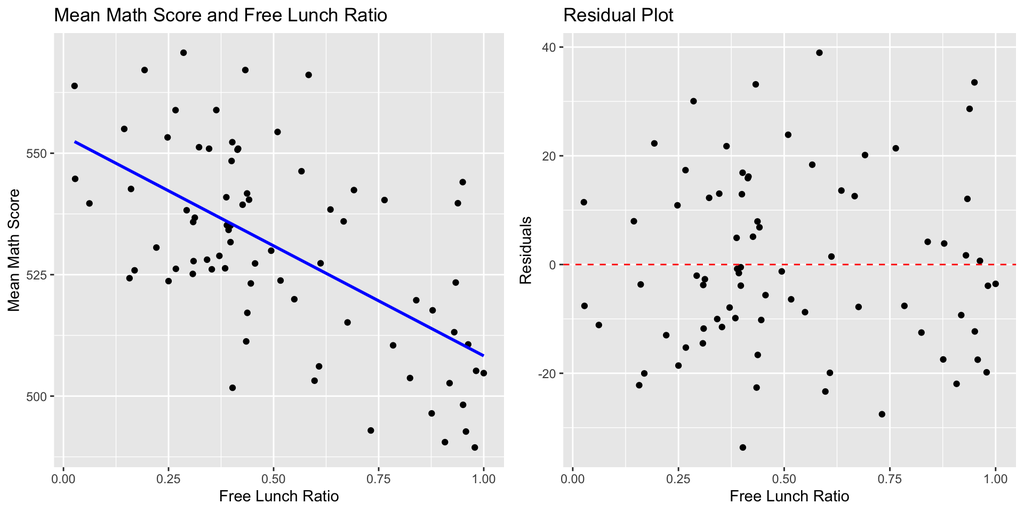

The figure above indicates a strong relationship between mean math score and free lunch ratio. The slope of the regression line indicates that an increase in the Free Lunch Ratio lead to a decrease in the Mean Math Score. In addition, the variance of the residuals is constant across all levels of the independent variable.

### 8.3 Conclusion

Based on our extended analysis with linear regression above, we may conclude that there exists a negative linear association between the free lunch ratio, which serves as an indicator for parental income levels, and mean math score per school. This suggests that students from lower-income backgrounds may face challenges that impact their academic performance in mathematics.

For remedy for this social issue, government-level support for students from economically disadvantaged backgrounds should be made. This could include providing additional resources and support in schools with higher proportions of students receiving free lunch.

which may include:

1. Targeted tutoring and counseling
2. Mentorship programs
3. ensure access to educational resources

Additionally, People should focus on improving access to quality education and economic opportunities for disadvantaged students to narrow the academic performance gap in mathematics between high income students which may ultimately lead to academic success for all students regardless of economic status.

# Acknowledgement

Sehee Han

Daehyun Chung

# Reference

Langsrud, Ø. (2003), “ANOVA for Unbalanced Data: Use Type II Instead of Type III Sums of Squares,” Statistics and Computing, 13, (pp. 163-167)

Kutner, M.H., Nachtsheim, C.J., Neter, J., and Li, W. (2005). Applied Linear Statistical Models, 5th edition. (pp. 951-977)

Achilles, C. M. (2012). NCPEA Policy Brief CLASS-SIZE POLICY: THE STAR EXPERIMENT AND RELATED CLASS-SIZE STUDIES, Volume 1, Number 2, October 2012. National Council of Professors of Educational Administration (NCPEA)

C.M. Achilles; Helen Pate Bain; Fred Bellott; Jayne Boyd-Zaharias; Jeremy Finn; John Folger; John Johnston; Elizabeth Word, 2008, “Tennessee’s Student Teacher Achievement Ratio (STAR) project”

Finn, J.D., Boyd-Zaharias, J., Fish, R.M., & Gerber, S.B. (2007). “Project STAR and Beyond: Database User’s Guide” HEROS, Incorporated.

# Code appendix

https://github.com/hewonahn/origin/tree/main/school_work/STA207